# HW 1

SDS 322E

September 06, 2021

#### Enter your name and EID here

Alice Gee ag67642

**Please submit as an HTML file on Canvas before the due date**

*For all questions, include the R commands/functions that you used to find your answer. Answers without supporting code will not receive credit.*

##### How to submit this assignment

> All homework assignments will be completed using R Markdown. These `.Rmd` files consist of text/syntax (formatted using Markdown) alongside embedded R code. When you have completed the assignment (by adding R code inside codeblocks and supporting text outside codeblocks), create your document as follows:
> - Click the “Knit” button (above)
> - Fix any errors in your code, if applicable
> - Upload the HTML file to Canvas

## Q1 (1 pts)

##### The dataset `quakes` contains information about earthquakes occurring near Fiji since 1964. The first few observations are listed below.

```r
head(quakes)
```

```
##      lat   long depth mag stations
## 1 -20.42 181.62   562 4.8       41
## 2 -20.62 181.03   650 4.2       15
## 3 -26.00 184.10    42 5.4       43
## 4 -17.97 181.66   626 4.1       19
## 5 -20.42 181.96   649 4.0       11
## 6 -19.68 184.31   195 4.0       12
```

##### How many observations are there of each variable (i.e., how many rows are there; show using code)? How many variables are there total (i.e., how many columns are in the dataset)? You can read more about the dataset [here](https://stat.ethz.ch/R-manual/R-patched/library/datasets/html/quakes.html) *Do not forget to include the code you used to find the answer each question*

```r
nrow(quakes)
```

```
## [1] 1000
```

```r
ncol(quakes)
```

```
## [1] 5
```

*Your typed answer goes here. 1-2 sentences only.* There are 1000 observations per variable. There are 5 variables total.

## Q2 (2 pts)

##### What are the minimum, maximum, mean, and median values for the variables `mag` and `depth`? Note that there are many functions that can be used to answer this question. If you chose to work with each variable separately, recall that you can access individual variables in a dataframe using the `$` operator (e.g., `dataset$variable`). Describe your answer in words.

```r
summary(quakes$mag)
```

```
##    Min. 1st Qu.  Median    Mean 3rd Qu.    Max.
##    4.00    4.30    4.60    4.62    4.90    6.40
```

```r
summary(quakes$depth)
```

```
##    Min. 1st Qu.  Median    Mean 3rd Qu.    Max.
##    40.0    99.0   247.0   311.4   543.0   680.0
```

*Your typed answer goes here. 1-2 sentences only.* The minimum, maximum, mean, and median values for the variable ‘mag’ are 4.00, 6.40, 4.62, and 4.60 respectively. The minimum, maximum, mean, and median values for the variable ‘depth’ are 40.0, 680.0, 311.4, and 247.0 respectively.

## Q3

##### Recall how logical indexing of a dataframe works in R. To refresh your memory, in the example code below I ask R for the median magnitude for quakes whose longitude is greater than 175. The two ways produce equivalent results.

```r
median(quakes$mag[quakes$long>175])
```

```
## [1] 4.5
```

```r
median(quakes[quakes$long>175,]$mag) #this is the more conventional notation
```

```
## [1] 4.5
```

### 3.1 (1 pt)

##### Explain what each of the two lines of code are doing in words. Specifically, why do we need to use the comma in the second case but not in the first? Remember that the `$` selects a single variable and that `[ ]` are used for indexing whatever object came before (either a single variable or a dataframe).

*Your answer goes here. 1-2 sentences only.* The two lines of code are returning the median ‘mag’ value for quakes that had a ‘long’ value greater than 175. You need the comma in the second line of code since it is making the call for rows that are longer than 175, and the comma specifies you want all the corresponding columns to such rows (to which you then choose to focus on the ‘mag’ column); You do not need a comma in the first line of code since we restrict the search to the column ‘mag’ before searching through which corresponding rows have a ‘long’ value greater than 175.

### 3.2 (3 pts)

##### What is the mean of the variable `mag` when `depth` is *greater than* the median depth? What is the mean of the variable `mag` when `depth` is *less than* the median depth? What does this suggest about the relationship between an earthquake’s depth and its magnitude?

```r
mean(quakes[quakes$depth > median(quakes$depth),]$mag)
```

```
## [1] 4.5232
```

```r
mean(quakes[quakes$depth < median(quakes$depth),]$mag)
```

```
## [1] 4.7176
```

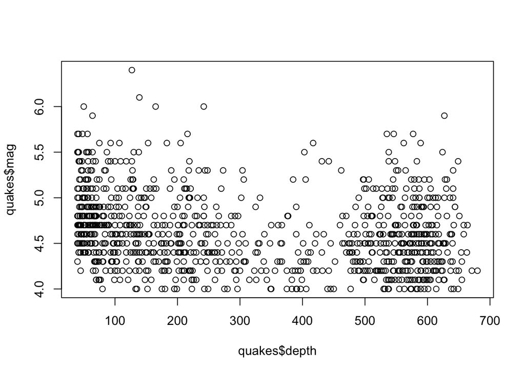

```r
plot(quakes$depth, quakes$mag)
```

*Your answer goes here. 1-2 sentences only.* The mean ‘mag’ when ‘depth’ is greater than the median depth is 4.5232; The mean ‘mag’ when ‘depth’ is less than the median depth is 4.7176. This data indicates that quakes with a smaller ‘depth’ may have a larger ‘mag’ compared to a different quake with a larger ‘depth’; there is not enough data to make a claim such that there is an inverse relationship as the distribution of values would be needed: As shown by the scatterplot, there is an inverse relationship between depth and maximum magnitude up until a certain depth, but after that, there is no distinct trend. It would be an overstatement to claim an inverse relationship exists for all depths and magnitudes.

### 3.3 (2 pts)

##### What is the standard deviation of the variable `lat` when `depth` is *greater than* the median depth? What is the standard deviation of the variable `lat` when `depth` is *less than* the median depth? What does this suggest about the relationship between an earthquake’s latitude and it’s depth?

```r
sd(quakes[quakes$depth > median(quakes$depth),]$lat)
```

```
## [1] 3.577252
```

```r
sd(quakes[quakes$depth < median(quakes$depth),]$lat)
```

```
## [1] 6.1501
```

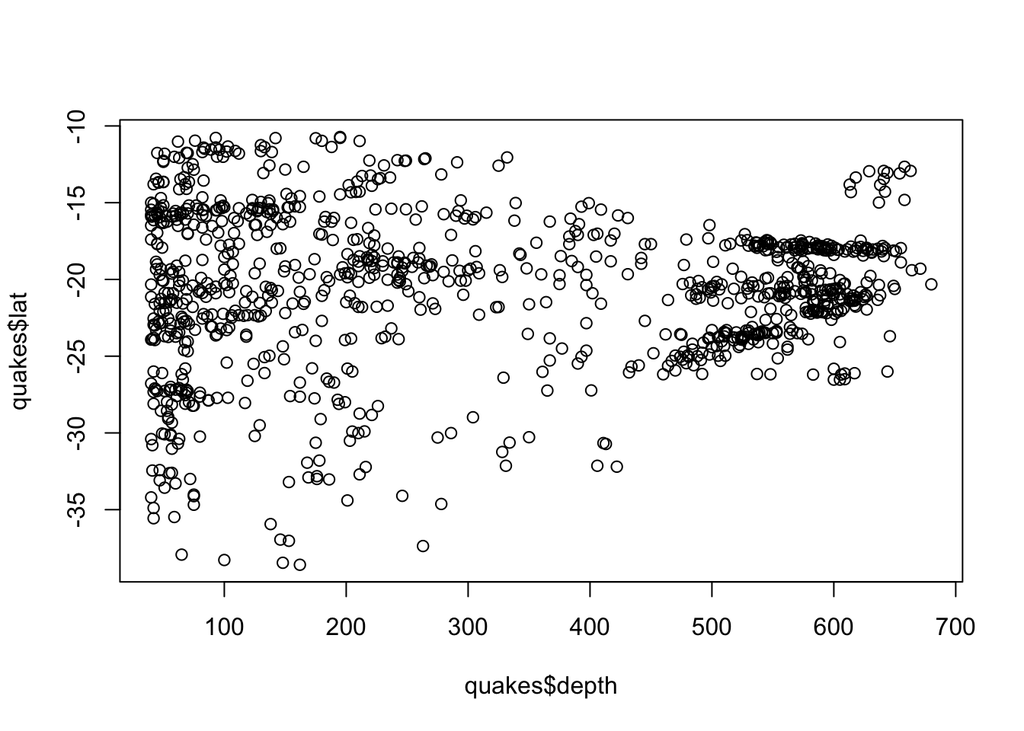

```r
plot(quakes$depth, quakes$lat)
```

*Your answer goes here. 1-2 sentences only.* The standard deviation for ‘lat’ when ‘depth’ is greater than the median depth is 3.577252; The standard deviation for ‘lat’ when ‘depth’ is less than the median depth is 6.1501. This data suggests quakes with a greater ‘depth’ more consistently occur within a certain [smaller] range of ‘lat’ values compared to quakes with a smaller ‘depth’ which occur at a much larger range of ‘lat’ values.

## Q4 (2 pts)

##### The variable `depth` is measured in kilometers. Create a new variable called `depth_m` that gives depth **in meters rather than kilometers** and add it to the dataset `quakes`. To help get you started, I have given you code that creates the new variable but fills it with `NA` values. Overwrite the `NA`s below by writing code on the right-hand side of the assignment operator (`<-`) that computes the requested transformation. Print out the first few rows of the updated dataset using `head()`.

```r
# update the code below by replacing the NA with the correct expression to convert to meters
quakes$depth_m <- quakes$depth * 1000
head(quakes)
```

```
##      lat   long depth mag stations depth_m
## 1 -20.42 181.62   562 4.8       41  562000
## 2 -20.62 181.03   650 4.2       15  650000
## 3 -26.00 184.10    42 5.4       43   42000
## 4 -17.97 181.66   626 4.1       19  626000
## 5 -20.42 181.96   649 4.0       11  649000
## 6 -19.68 184.31   195 4.0       12  195000
```

## Q5

##### Let’s make some plots in base R.

### 5.1 (2 pt)

##### Create a boxplot of `depth` using the `boxplot()` function. Describe where you see the min, max, and median (which you calculated in question 2) in this plot.

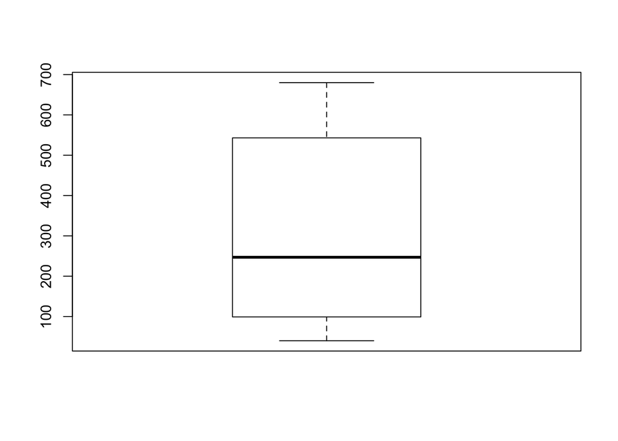

```r
boxplot(quakes$depth)
```

*Your answer goes here. 1-2 sentences only.* The minimum, maximum, mean, and median values for the variable ‘depth’ are 40.0, 680.0, 311.4, and 247.0 respectively. On the boxplot, the minimum value (40.0) is the lower tail of the plot, the maximum value (680.0) is the upper tail of the plot, and the median value (247.0) is the thicker line in the box.

### 5.2 (2 pt)

##### Create a histogram of `depth` using the `hist()` function. What important information does the histogram provide that the boxplot does not?

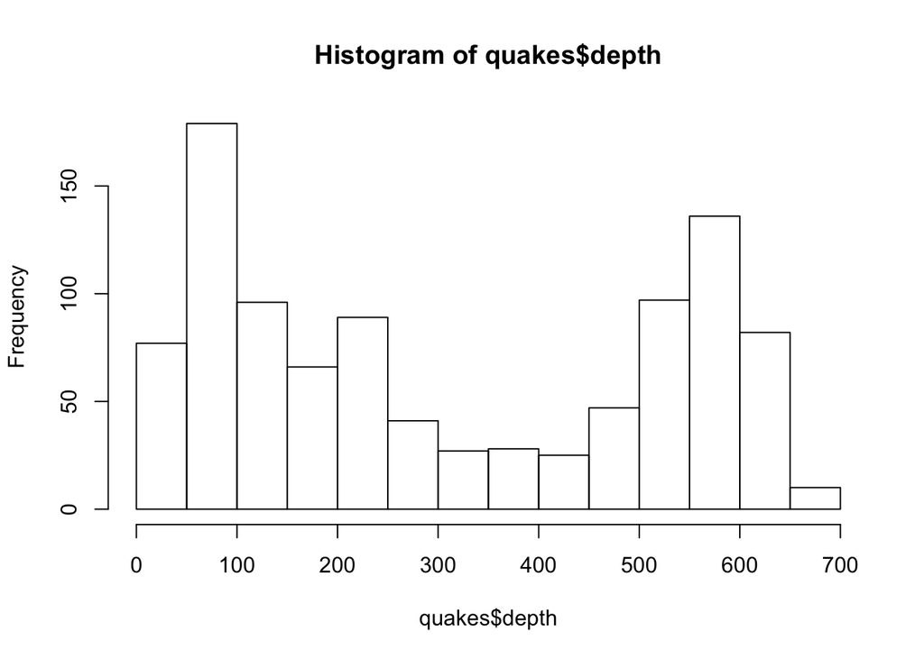

```r
hist(quakes$depth)
```

*Your answer goes here. 1-2 sentences only.* The histogram better illustrates the distribution of values compared to a boxplot. While both can indicate whether the distributions are normal or skewed, the histogram provides a more clear view of the distribution such as the two peaks/hills of data distribution (which cannot be seen in the boxplot).

### 5.3 (2 pt)

##### Create a scatterplot by plotting variables `mag` and `stations` against each other using the `plot()` function. Note that to generate a scatterplot, the `plot()` takes two arguments: the x-axis variable and the y-axis variable. Describe the relationship between the two variables.

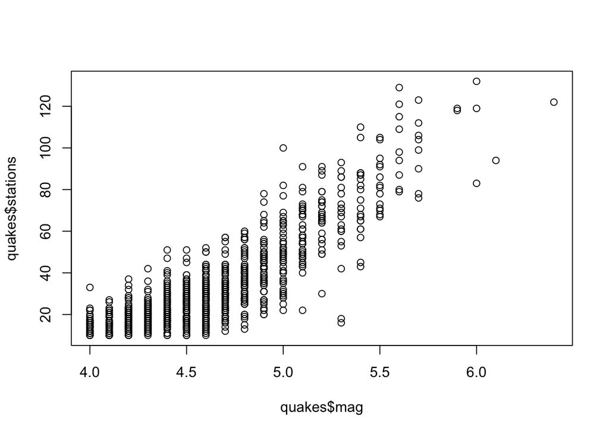

```r
plot(quakes$mag, quakes$stations)
```

### 5.4 (3 pt)

##### Create scatterplot of the quakes’ geographic locations by plotting `long` on the x-axis and `lat` on the y-axis. Using this plot, and the map/link below (note the two trenches), and some of the techniques you practiced above, are deeper quakes more likely to originate east or west of Fiji?

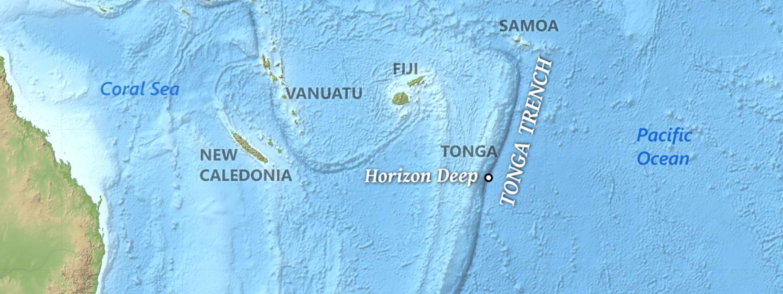

[Link to location on Google maps](https://www.google.com/maps/@-20.1679389,175.7587479,3513560m/data=!3m1!1e3)

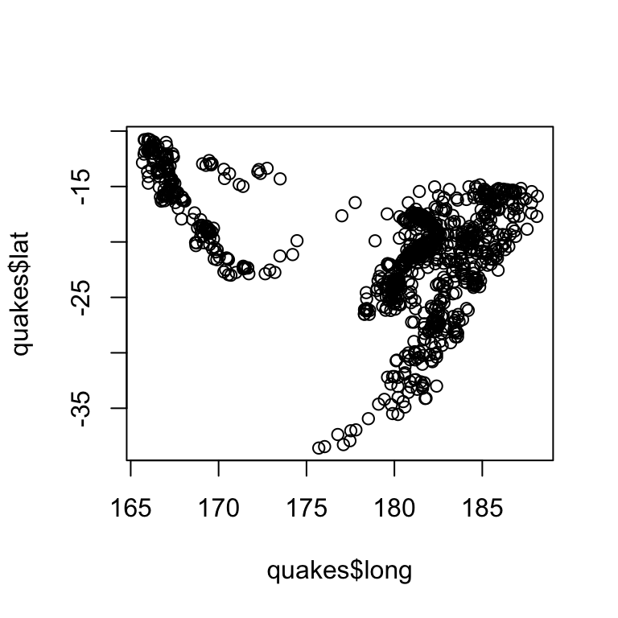

```r
plot(quakes$long, quakes$lat)
```

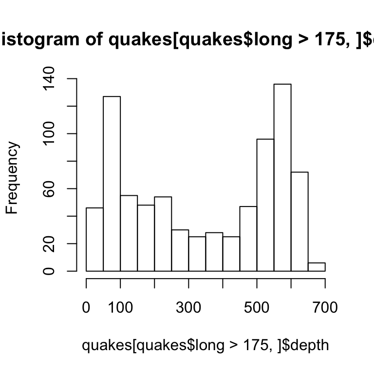

```r
hist(quakes[quakes$long > 175,]$depth)
```

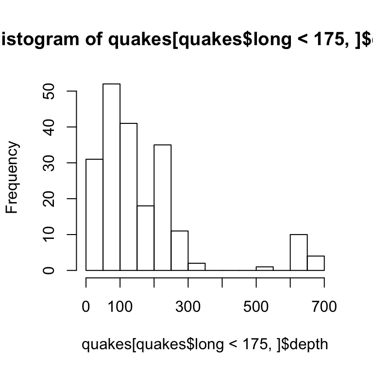

```r
hist(quakes[quakes$long < 175,]$depth)
```

```r
mean(quakes[quakes$long > 175,]$depth)
```

```
## [1] 347.9182
```

```r
mean(quakes[quakes$long < 175,]$depth)
```

```
## [1] 169.639
```

*Your answer goes here. 1-2 sentences only.* The mean ‘depth’ for quakes in East Fiji is 347.918, while the mean ‘depth’ for quakes in West Fiji is 169.639. Moreover, the histograms show a significantly higher frequency of deeper quakes in East Fiji compared to West Fiji, thus it is reasonable to conclude that deeper quakes are more likely to originate in East Fiji.

```
## [1] "2021-09-06 18:00:24 CDT"
```

[output not shown]